# EDA: Salaries of MLB Batters from 1985 to 2020

### II. Identifying Predictors for Postseason

We will attempt to identify variables that would predict a team’s likelihood of entering the postseason (a period in the end of the MLB regular season where the best teams compete for the World Series Title in a tournament fashion)

#### A. Setting up

Because we are now talking in terms of teams, I created a new dataframe that contains statistic of a team’s season by merging the data with group_by.

I also created new variables that measures the ratio of these statistics for a whole team’s season. The team’s collective batting average `total_BA`, the team’s collective strikeout percentage `total_Kperc`, etc. `GIDP` refers to “Grounded in double play” which is a bad thing for the batter and produces two outs.

```r
teamsummary <- df %>%
  group_by(yearID, teamID) %>%
  summarise(total_AB = sum(AB, na.rm=TRUE), total_H = sum(H, na.rm=T),
            total_HR = sum(HR, na.rm = T),  total_R = sum(R, na.rm = T),
            total_SO = sum(SO, na.rm = T), total_salary = sum(salary, na.rm = T),
            total_GIDP = sum(GIDP, na.rm = T)) %>%
  mutate(total_BA = total_H/total_AB,
         total_Kperc = total_SO/total_AB,
         total_HRperc = total_HR/total_AB,
         total_RRatio = total_R/total_AB,
         total_GIDPperc = total_GIDP/total_AB) %>%
  arrange(yearID, teamID)
head(teamsummary)
```

```
## # A tibble: 6 x 14
## # Groups:   yearID [1]
##   yearID teamID total_AB total_H total_HR total_R total_SO total_salary
##    <dbl> <chr>     <dbl>   <dbl>    <dbl>   <dbl>    <dbl>        <dbl>
## 1   1985 ATL        5526    1359      126     632      849     14032000
## 2   1985 BAL        5517    1451      214     818      908     11560712
## 3   1985 BOS        5720    1615      162     800      816     10299227
## 4   1985 CAL        5442    1364      153     732      902     12591227
## 5   1985 CHA        5470    1386      146     736      843      9846178
## 6   1985 CHN        5492    1397      150     686      937     12702917
## # ... with 6 more variables: total_GIDP <dbl>, total_BA <dbl>,
## #   total_Kperc <dbl>, total_HRperc <dbl>, total_RRatio <dbl>,
## #   total_GIDPperc <dbl>
```

I then left merged this dataframe with another dataframe only containing the team’s postseason appearance status by creating a new dataframe only containing the team, its year, and the postseason appearance stats `postseason_app`. Code is shown below

```r
teamsPSapp <- df %>%
  select(teamID, yearID, postseason_app) %>%
    unique()
teamsummary <- left_join(teamsummary, teamsPSapp, by = c("teamID", "yearID")) %>%
  select(yearID, teamID, postseason_app, total_BA, total_Kperc,
         total_HRperc, total_RRatio, total_GIDPperc, total_salary, everything())%>%
  arrange(yearID, teamID)
```

Finally, I included another variable that displays the `yearID` as factors instead of integers.

```r
teamsummary$yearIDfactor = as.factor(teamsummary$yearID)
head(teamsummary)
```

```
## # A tibble: 6 x 16
## # Groups:   yearID [1]
##   yearID teamID postseason_app total_BA total_Kperc total_HRperc total_RRatio
##    <dbl> <chr>  <chr>             <dbl>       <dbl>        <dbl>        <dbl>
## 1   1985 ATL    N                 0.246       0.154       0.0228        0.114
## 2   1985 BAL    N                 0.263       0.165       0.0388        0.148
## 3   1985 BOS    N                 0.282       0.143       0.0283        0.140
## 4   1985 CAL    N                 0.251       0.166       0.0281        0.135
## 5   1985 CHA    N                 0.253       0.154       0.0267        0.135
## 6   1985 CHN    N                 0.254       0.171       0.0273        0.125
## # ... with 9 more variables: total_GIDPperc <dbl>, total_salary <dbl>,
## #   total_AB <dbl>, total_H <dbl>, total_HR <dbl>, total_R <dbl>,
## #   total_SO <dbl>, total_GIDP <dbl>, yearIDfactor <fct>
```

##### B. Total Batting Average

Can we predict a team’s likelihood to enter the postseason by looking at the team’s collective batting average?

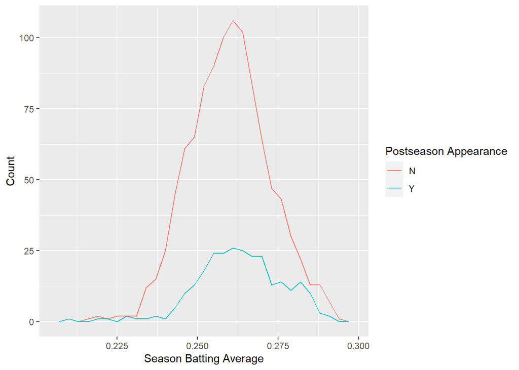

```r
teamsummary %>%
  ggplot(mapping = aes(x = total_BA)) +
  geom_freqpoly(mapping = aes(colour = postseason_app), binwidth = 0.003) +
  labs(x = "Season Batting Average", y = "Count", colour = "Postseason Appearance")
```

We would be comparing the shift and the pattern of the graph rather than the scale of these graphs, since there are obviously more data points for teams that didn’t make the postseason. There doesn’t seem like an obvious correlation, since the shape is pretty similar between the two graphs.

##### C. Runs

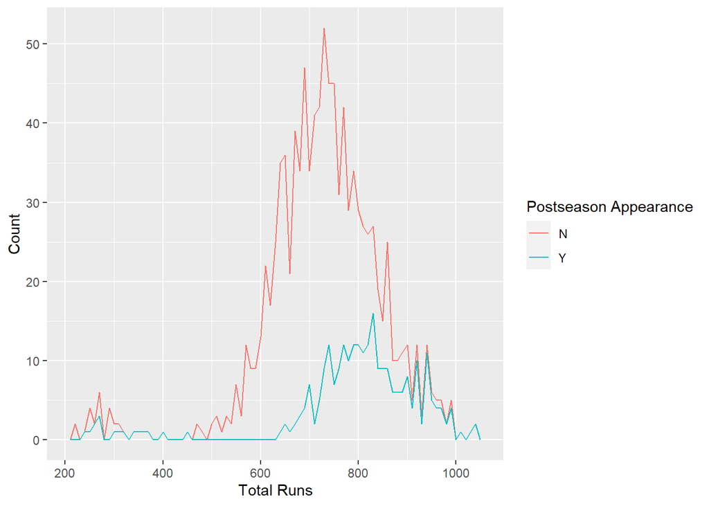

```r
teamsummary %>%
  ggplot(mapping = aes(x = total_R)) +
  geom_freqpoly(mapping = aes(colour = postseason_app), binwidth = 10) +
  labs(x = "Total Runs", y = "Count", colour = "Postseason Appearance")
```

It seems that the postseason graph is more skewed left (with a more rightward peak), meaning that teams that appeared on the postseason tend to have higher runs. Team’s total runs do seem like a better indicator at least compared to the collective batting average. We can see a similar trend with `total_RRatio`, or a team’s calculated run per At Bat.

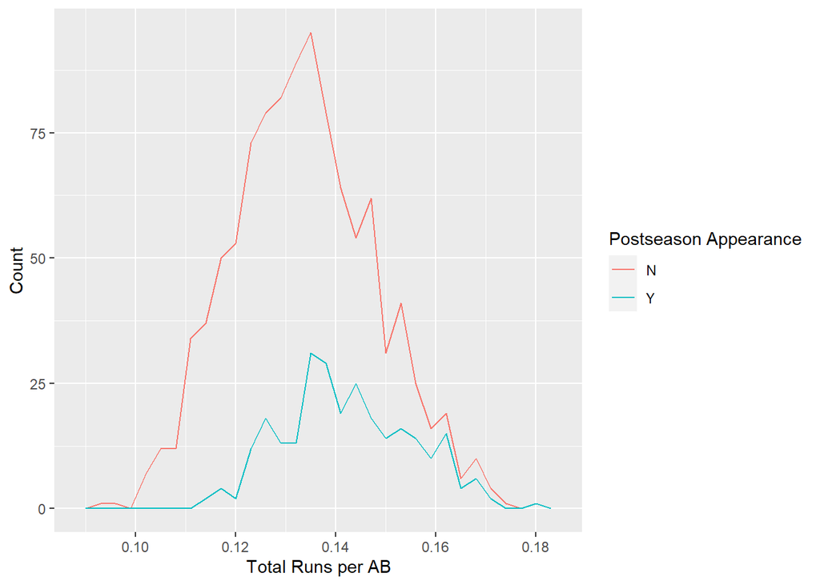

```r
teamsummary %>%
  ggplot(mapping = aes(x = total_RRatio)) +
  geom_freqpoly(mapping = aes(colour = postseason_app), binwidth = 0.003) +
  labs(x = "Total Runs per AB", y = "Count", colour = "Postseason Appearance")
```

Although the postseason team’s graph seems a bit more rightward, I think that `total_R` is a better indicator of a team’s postseason appearance likelihood. This makes sense given that a team’s win is determined by the hard number of runs scored, not “run scored per at bat.”

##### D. Homeruns

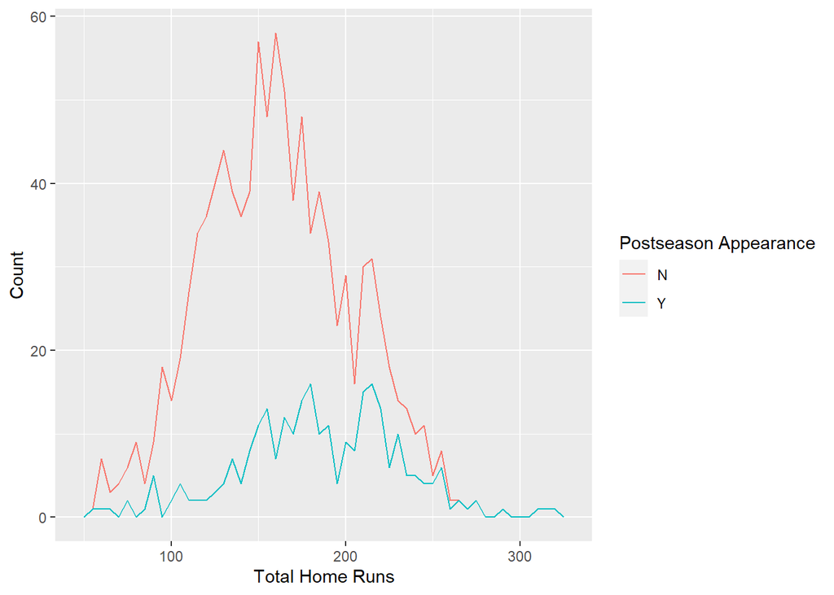

```r
teamsummary %>%
  ggplot(mapping = aes(x = total_HR)) +
  geom_freqpoly(mapping = aes(colour = postseason_app), binwidth = 5) +
  labs(x = "Total Home Runs", y = "Count", colour = "Postseason Appearance")
```

This is a similar graph to above `Total Runs` graph. There is an obvious skew left (rightward shift) for the postseason graph compared to the regular season graph. This makes sense because the number of home runs is directly correlated with the number of runs scored by a team.

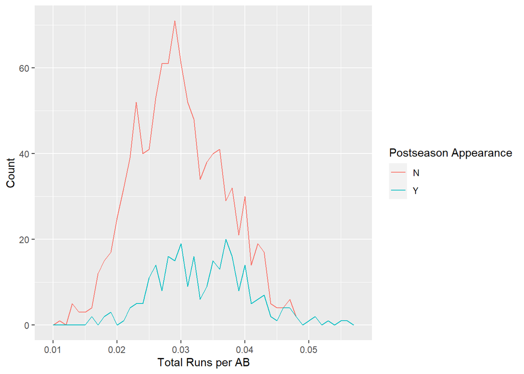

```r
teamsummary %>%
  ggplot(mapping = aes(x = total_HRperc)) +
  geom_freqpoly(mapping = aes(colour = postseason_app), binwidth = 0.001) +
  labs(x = "Total Runs per AB", y = "Count", colour = "Postseason Appearance")
```

Again, the HR ratio graph is similar to the Run ratio graph. You can see a clear rightward shift by the postseason graph, but it’s not as evident as the “Total home run” graph.